# 11. Evaluate the Perturbation Finetuned Model & Generate Posterior Estimation

Author: Tianze (Vincent) Luo  
Date : 2025-12-09 Created

```python
######## Load modules ########
from __future__ import annotations #default now for name.error issue
import os
## ensure model trains on one GPU
os.environ["CUDA_VISIBLE_DEVICES"] = "0"
os.environ["WORLD_SIZE"] = "1"
import pickle
from datetime import datetime
import numpy as np
import random
import pandas as pd
import matplotlib.pyplot as plt
import seaborn as sns
SEED = 1234
random.seed(SEED)
np.random.seed(SEED)
import scipy
from tqdm import tqdm
import torch

# Cell2Sentence imports
import cell2sentence as cs
# from cell2sentence.utils import benchmark_expression_conversion, reconstruct_expression_from_cell_sentence
from cell2sentence import utils
from cell2sentence.tasks import embed_cells, predict_cell_types_of_data
from cell2sentence.prompt_formatter import get_cell_sentence_str, PromptFormatter #for custom prompt

# Hugging Face
from transformers import TrainingArguments, AutoModelForCausalLM
from datasets import Dataset # Arrow

# Single-cell libraries
import scanpy as sc
import anndata as ad
from collections import Counter, defaultdict #count table

sc.set_figure_params(dpi=300, color_map="viridis_r", facecolor="white", )
sc.settings.verbosity = 3  # verbosity: errors (0), warnings (1), info (2), hints (3)
sc.logging.print_header()
```

```
scanpy==1.9.8 anndata==0.9.2 umap==0.5.7 numpy==1.24.4 scipy==1.10.1 pandas==2.0.3 scikit-learn==1.3.2 statsmodels==0.14.1 pynndescent==0.5.13
```

```python
# Define the directories
output_dir = "/ix/ccdg/storage3/til177/ParkLab/Project_C2S_scFM/code/tutorials/data_PerturbSeq/finetunedModel_2025-12-09-16_44_46_testFinetune_perturbation_prediction/checkpoint-500"
save_dir   = "/ix/ccdg/storage3/til177/ParkLab/Project_C2S_scFM/code/tutorials/data_PerturbSeq"
```

```python
# Define device
device = "cuda" if torch.cuda.is_available() else "cpu"
device
```

```
'cpu'
```

## 11.1 Model Selection - Visualize Train/Val loss curves for the last checkpoint

```
/ix/ccdg/storage3/til177/ParkLab/Project_C2S_scFM/code/tutorials/data_PerturbSeq/finetunedModel_2025-12-09-16_44_46_testFinetune_perturbation_prediction/checkpoint-500
True
```

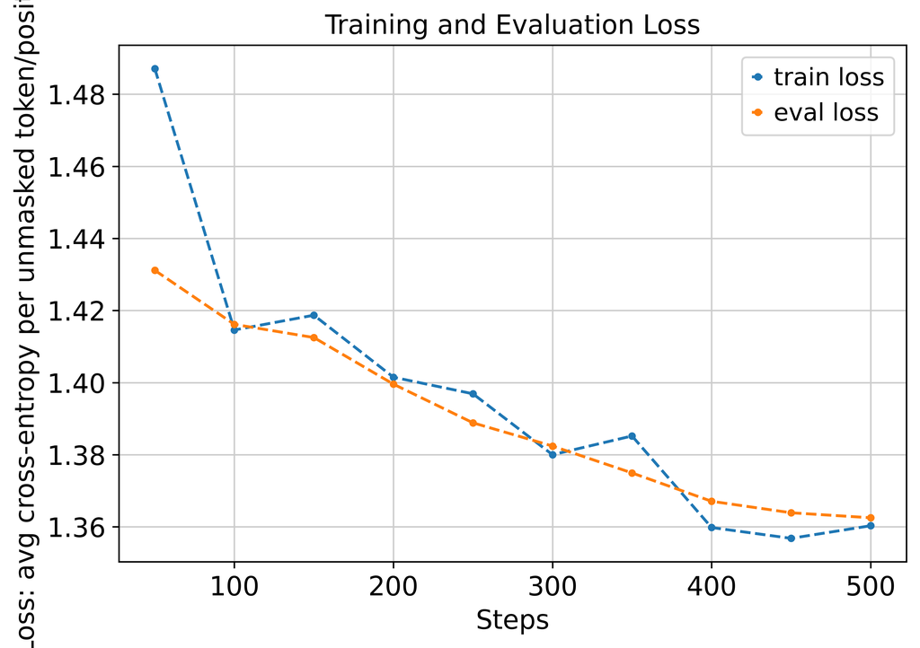

```python
import json

state_file = os.path.join(output_dir, "trainer_state.json")

# 1. Load the state file
with open(state_file, "r") as f:
    state = json.load(f)
# Check best model
print(state["best_model_checkpoint"])
# Load history
log_history = state["log_history"]

# 2. Extract train and eval losses
train_steps, train_losses = [], []
eval_steps, eval_losses = [], []

for entry in log_history:
    # print(entry)
    if "loss" in entry and "step" in entry: #print(entry["step"])
        train_steps.append(entry["step"])
        train_losses.append(entry["loss"])
    if "eval_loss" in entry and "step" in entry:
        eval_steps.append(entry["step"])
        eval_losses.append(entry["eval_loss"])

print(train_steps == eval_steps)
# print(train_losses)

# 3. Plot
plt.figure(figsize=(7, 5))
plt.plot(train_steps, train_losses, '--.', label="train loss")
plt.plot(eval_steps,  eval_losses,  '--.', label="eval loss")
plt.xlabel("Steps")
plt.ylabel("Loss: avg cross‑entropy per unmasked token/position")
plt.title("Training and Evaluation Loss")
plt.legend()
plt.grid(True)
plt.tight_layout()

# save_path = os.path.join(output_dir, "loss_curves.png")
# plt.savefig(save_path, dpi=500)

plt.show()
# print(f"Saved figure to {save_path}")
```

### Healthy sign

- Early training
  - Train loss: should drop fairly quickly at the beginning.
  - Eval loss: should also decrease, maybe a bit more slowly, and be **a bit higher than train loss**.
  - This tells you:
    - The model is learning patterns in your data.
    - It’s also generalizing to validation, not just memorizing batches.
- Mid–late training
  - Both curves should either:
    - Keep **going down but more slowly**, or
    - Reach a plateau and **wiggle around** roughly the same value.
  - At this stage:
    - If eval loss is still slowly improving, more training may help.
    - If eval loss is flat but train loss keeps going down, you’re on the edge of overfitting.

### Warning sign

A. Overfitting

- Train loss: keeps decreasing.
- Eval loss: Decreases at first, then bottoms out and starts to increase.

B. Underfitting / not learning

- Train loss: barely decreases; stays near its starting value.
- Eval loss: also mostly flat.

## 11.2 Generate Predictions with the Finetuned Model

After finetuning, let's load our new model and use it to predict the response to a perturbation for a cell from our test set.

**First, repeat the first part of `c2s_tvl_10` to load `formatted_arrow_ds`**

```python
######## Re-load Perturbation Data ########
DATA_PATH = "/ix/ccdg/storage3/til177/ParkLab/Project_C2S_scFM/code/tutorials/data_PerturbSeq/GSE264667_jurkat_processed.h5ad"
adata = ad.read_h5ad(DATA_PATH)
# print(adata)             # check dimension
# print(adata.var_names)   # will be used to create the __cell sentences__
# print(adata.obs.columns) # check colnames (for next step)
# print(adata.X.max())     # check max value (log10 transformation expects a maximum value somewhere around 3 or 4)

# target_gene_counter = Counter(adata.obs['target_gene'])
# # print(len(target_gene_counter))
# print(target_gene_counter.most_common(20)) #('non-targeting', 11742)!


######## AnnData -> Arrow ########
# We'll keep all relevant columns for our new task
adata_obs_cols_to_keep = ['batch_var','cell_type','target_gene','gene_id','mitopercent','UMI_count']

# Create Arrow dataset and vocabulary
arrow_ds, vocabulary = cs.CSData.adata_to_arrow(
    adata=adata,
    random_state=SEED,
    sentence_delimiter=' ',
    label_col_names=adata_obs_cols_to_keep
)
print(arrow_ds)

# # Check single-cell info
# sample_idx = 0
# print(arrow_ds[sample_idx])
# ##   Check cell sentence length
# print(len(arrow_ds[sample_idx]["cell_sentence"].split(" ")))  # Cell 0 has 4016 nonzero expressed genes
# ##   Check feature info
# print(type(vocabulary))
# print(len(vocabulary))
# print(list(vocabulary.items())[:10]) #fist 10, also contains the number of cells 'that gene' was expressed in.
```

```
Dataset({
    features: ['cell_name', 'cell_sentence', 'batch_var', 'cell_type', 'target_gene', 'gene_id', 'mitopercent', 'UMI_count'],
    num_rows: 257412
})
```

```python
######## Custom Prompt Formatting for Perturbation Prediction ########

#  The input provides the {control cell} and the {perturbation}, asking for the {perturbed result}.
custom_input_prompt_template = """Given the following cell sentence of {num_genes} expressed genes representing a cell's basal state, predict the cell sentence after applying the perturbation: {perturbation_name}.
Control cell sentence: {control_cell_sentence}.

Perturbed cell sentence:"""

# The answer is simply the target cell sentence.
answer_template = "{perturbed_cell_sentence}."


#### Create PerturbationPromptFormatter (format_hf_ds outputs: formatted HF Arrow DataSet) ####
class PerturbationPromptFormatter(PromptFormatter):
    def __init__(self,
        task_name,
        input_prompt,
        answer_template,
        top_k_genes,
        perturbation_col='target_gene',
        control_label='non-targeting'
    ):
        """
        Initializes the custom prompt formatter.

        Args:
            task_name (str): The name for this task.
            input_prompt (str): The template for the model's input.
            answer_template (str): The template for the model's expected response.
            top_k_genes (int): The number of top genes to include in the cell sentence.
            perturbation_col (str): The column name in the dataset that contains perturbation info.
            control_label (str): The label used to identify control cells in the perturbation_col.
        """
        super().__init__()
        self.task_name = task_name
        self.input_prompt = input_prompt
        self.answer_template = answer_template
        self.top_k_genes = top_k_genes
        self.perturbation_col = perturbation_col
        self.control_label = control_label
        assert top_k_genes > 0, "'top_k_genes' must be an integer > 0"

    def format_hf_ds(self, hf_ds):
        """
        Custom formatting function for perturbation prediction. This function creates pairs of
        (control, perturbed) cells by sampling from a global pool of control cells.
        """
        model_inputs_list = []
        responses_list = []

        # 1. Separate all cells into a global control pool and a dict of perturbed cells
        control_indices = []
        pert_to_indices = defaultdict(list)

        print("Grouping cells by perturbation and identifying global controls...")
        for i, sample in enumerate(hf_ds):
            if sample[self.perturbation_col] == self.control_label:
                control_indices.append(i)
            else:
                pert_to_indices[sample[self.perturbation_col]].append(i)

            # For each cell (sample) in the dataset:
            # If it's a control cell (e.g., target_gene == 'non-targeting'): add its index to control_indices
            # If it's perturbed (e.g., target_gene == 'BRCA1'): add its index to the pert_to_indices dictionary under that perturbation name

        assert len(control_indices) > 0, "No control cells found. Cannot create pairs."
        print(f"Found {len(control_indices)} control cells.")
        print(f"Found {len(pert_to_indices)} unique perturbations.")

        # 2. Create prompt-response pairs by iterating through perturbed cells
        print("Creating control-perturbed pairs...")
        for pert_name, perturbed_indices in tqdm(pert_to_indices.items()):
            for perturbed_idx in perturbed_indices:
                # Pair each perturbed cell with a random control cell from the global pool
                control_idx = random.choice(control_indices)

                control_sample = hf_ds[control_idx]
                perturbed_sample = hf_ds[perturbed_idx]

                # Format control cell sentence
                control_sentence, num_genes_str = get_cell_sentence_str(#https://github.com/vandijklab/cell2sentence/blob/a6efaf079f98491d4723ced44b929936b94368aa/src/cell2sentence/prompt_formatter.py#L31
                    control_sample,
                    num_genes=self.top_k_genes
                )
                # Format perturbed cell sentence
                perturbed_sentence, _ = get_cell_sentence_str(
                    perturbed_sample,
                    num_genes=self.top_k_genes
                )

                #### Matches the template fstring ####
                # Format the model input string using the perturbation name
                model_input_str = self.input_prompt.format(
                    num_genes=num_genes_str,
                    perturbation_name=pert_name,
                    control_cell_sentence=control_sentence
                )
                # Format the response string
                response_str = self.answer_template.format(
                    perturbed_cell_sentence=perturbed_sentence
                )

                model_inputs_list.append(model_input_str)
                responses_list.append(response_str)

        # Create the final Hugging Face Dataset
        ds_split_dict = {
            "sample_type": [self.task_name] * len(model_inputs_list),
            "model_input": model_inputs_list,
            "response": responses_list,
        }
        ds = Dataset.from_dict(ds_split_dict)
        return ds

#### Test run to see the results (this will automatically done in `csmodel.fine_tune()`)
# Initiate the formatter
task_name = "perturbation_prediction"
prompt_formatter = PerturbationPromptFormatter(
    task_name=task_name,
    input_prompt=custom_input_prompt_template,
    answer_template=answer_template,
    top_k_genes=200 # Using top 200 genes for this example. For real applications, ideal to use all nonzero expressed genes if possible.
)
# Format the dataset
formatted_ds = prompt_formatter.format_hf_ds(arrow_ds)
print(formatted_ds)
print(type(formatted_ds)) #datasets.arrow_dataset.Dataset
# Inspect a formatted sample
print("--- Formatted Sample ---")
print("#----Model input:----#")
print(formatted_ds[0]["model_input"], "\n")
print("#----Response:----#")
print(formatted_ds[0]["response"])
```

```
Grouping cells by perturbation and identifying global controls...
Found 11742 control cells.
Found 2393 unique perturbations.
Creating control-perturbed pairs...
```

```
Dataset({
    features: ['sample_type', 'model_input', 'response'],
    num_rows: 245670
})
<class 'datasets.arrow_dataset.Dataset'>
--- Formatted Sample ---
#----Model input:----#
Given the following cell sentence of 200 expressed genes representing a cell's basal state, predict the cell sentence after applying the perturbation: NELFE.
Control cell sentence: MALAT1 MT-CO3 MT-CO2 EEF1A1 RPL10 MT-ATP6 RPS2 RPS3A RPL13 GAPDH ACTB MT-CO1 RPS6 MT-CYB RPL6 PTMA RPS7 RPS23 TPT1 RPL19 RPS4X RPS19 RPL7A RACK1 MT-ND4 RPL18A RPL7 RPS12 RPS3 FTH1 RPS18 HSP90AA1 RPL3 RPS5 RPLP1 HMGB1 RPS27A RPL5 RPS14 TMSB4X RPL11 RPL9 RPS24 RPS15 RPLP0 TUBA1B…

Perturbed cell sentence:

#----Response:----#
MT-CO3 MT-ATP6 MALAT1 MT-CO2 MT-ND4 MT-CO1 EEF1A1 RPS2 MT-CYB RPS3 PTMA RPL10 RPL13 RPS3A TMSB4X ACTB GAPDH RPS18 RPS7 RPS19 RPS12 RPS6 RPS27A MT-ND1 RPL19 RACK1 HIST1H1D RPLP1 RPS15 RPS14 RPS23 RPS5 RPL13A TPT1 RPL18 RPL3 RPLP0 RPS4X RPL7A RPL30 MT-ND3 RPL11 RPL32 RPS16 HIST1H4C RPL15 RPL6 RPL28 TU…
```

**Now, start generating predictions with the Finetuned Model**

```python
final_ckpt_path = output_dir
final_ckpt_path
```

```
'/ix/ccdg/storage3/til177/ParkLab/Project_C2S_scFM/code/tutorials/data_PerturbSeq/finetunedModel_2025-12-09-16_44_46_testFinetune_perturbation_prediction/checkpoint-500'
```

```python
save_dir
```

```
'/ix/ccdg/storage3/til177/ParkLab/Project_C2S_scFM/code/tutorials/data_PerturbSeq'
```

```python
# Load the finetuned model & Save the best checkpoint as new CSModel
finetuned_model = cs.CSModel(
    model_name_or_path=final_ckpt_path, # Path is updated after finetuning
    save_dir=save_dir,
    save_name="perturbation_predictor_finetuned_final"
)
```

```
Using device: cpu
```

```python
finetuned_model.save_path
```

```
'/ix/ccdg/storage3/til177/ParkLab/Project_C2S_scFM/code/tutorials/data_PerturbSeq/perturbation_predictor_finetuned_final'
```

**Loading the final finetuned model checkpoint into a regular Hugging Face AutoModelForCausalLM and moving it to GPU/CPU.**

```python
final_model = AutoModelForCausalLM.from_pretrained(
    finetuned_model.save_path,
    cache_dir=os.path.join(save_dir, ".cache"), #where to store / reuse model files
    trust_remote_code=True
).to(device)
```

```python
final_model
```

```
GPTNeoXForCausalLM(
  (gpt_neox): GPTNeoXModel(
    (embed_in): Embedding(50304, 2048)
    (emb_dropout): Dropout(p=0.0, inplace=False)
    (layers): ModuleList(
      (0-15): 16 x GPTNeoXLayer(
        (input_layernorm): LayerNorm((2048,), eps=1e-05, elementwise_affine=True)
        (post_attention_layernorm): LayerNorm((2048,), eps=1e-05, elementwise_affine=True)
        (post_attention_dropout): Dropout(p=0.0, inplace=False)
        (post_mlp_dropout): Dropout(p=0.0, inplace=False)
        (attention): GPTNeoXSdpaAttention(
          (rotary_emb): GPTNeoXRotaryEmbedding()
          (query_key_value): Linear(in_features=2048, out_features=6144, bias=True)
          (dense): Linear(in_features=2048, out_features=2048, bias=True)
          (attention_dropout): Dropout(p=0.0, inplace=False)
        )
        (mlp): GPTNeoXMLP(
          (dense_h_to_4h): Linear(in_features=2048, out_features=8192, bias=True)
          (dense_4h_to_h): Linear(in_features=8192, out_features=2048, bias=True)
          (act): GELUActivation()
        )
      )
    )
    (final_layer_norm): LayerNorm((2048,), eps=1e-05, elementwise_affine=True)
    (rotary_emb): GPTNeoXRotaryEmbedding()
  )
  (embed_out): Linear(in_features=2048, out_features=50304, bias=False)
)
```

**Load dataset split (done in finetune() function, saved to output directory)**

```python
ft_dir="/ix/ccdg/storage3/til177/ParkLab/Project_C2S_scFM/code/tutorials/data_PerturbSeq/finetunedModel_2025-12-09-16_44_46_testFinetune_perturbation_prediction/"

with open(os.path.join(ft_dir, 'data_split_indices_dict.pkl'), 'rb') as f:
    data_split_indices_dict = pickle.load(f)

data_split_indices_dict.keys()
```

```
dict_keys(['train', 'val', 'test'])
```

```python
print(len(data_split_indices_dict['train']))
print(len(data_split_indices_dict['val']))
print(len(data_split_indices_dict['test']))
```

```
196781
24322
24567
```

```python
# Select a few unseen samples
formatted_test_ds = formatted_ds.select(data_split_indices_dict['test'][:10])
formatted_test_ds
```

```
Dataset({
    features: ['sample_type', 'model_input', 'response'],
    num_rows: 10
})
```

```python
# Select a sample from the test set for inference
sample_idx = 0
inference_prompt      = formatted_test_ds[sample_idx]['model_input']
ground_truth_response = formatted_test_ds[sample_idx]['response']

print("--- Inference Prompt ---")
print(inference_prompt)
```

```
--- Inference Prompt ---
Given the following cell sentence of 200 expressed genes representing a cell's basal state, predict the cell sentence after applying the perturbation: NELFE.
Control cell sentence: MT-CO3 MT-ATP6 MT-CO2 MT-ND4 MT-CO1 MT-CYB RPS2 GAPDH RPL13 RPS7 MT-ND1 EEF1A1 RPLP1 RPL7A RPL10 PTMA MT-ND3 RPS3 RPL6 RPS12 RPS3A MALAT1 RPL18A RPS6 ACTB RPS18 RPL37A RACK1 TMSB4X RPL8 RPS23 RPSA RPL18 RPS15 RPS27A RPL32 RPL11 MIF RPL5 RPL15 RPL19 RPL28 TUBA1B MT-ND2 RPL17 RP…

Perturbed cell sentence:
```

**Generate the prediction**

```python
predicted_response = finetuned_model.generate_from_prompt(
    model=final_model, # a c2s model
    prompt=inference_prompt,
    max_num_tokens=800 # max number of tokens to generate, ~4 tokens per gene
)
```

```python
print("\n--- Ground Truth Perturbed Cell ---")
print(ground_truth_response)
print("\n--- Predicted Perturbed Cell ---")
print(predicted_response)
```

```
--- Ground Truth Perturbed Cell ---
MT-CO3 MT-ATP6 MT-CO2 MT-CYB MT-ND4 MT-CO1 EEF1A1 GAPDH ACTB RPS2 MALAT1 HMGB1 RPL13 RPS15 RPS14 FTH1 RPS23 RPS18 RPS7 RPLP1 RPL10 RPS12 RPS5 MT-ND3 RPL29 RPS6 YBX1 HSP90AA1 PTMA RPL18A RPL37 RPL18 RPS3A RPL11 RPL17 RPL32 RPL30 MT-ND1 HINT1 RPS27A RPL28 PFN1 RPS19 RACK1 H2AFZ RPS3 RPS16 RPS9 TMSB4X …

--- Predicted Perturbed Cell ---
MT-ATP6 MT-CO3 MT-CO2 MT-CYB MT-CO1 MT-ND4 RPS2 EEF1A1 RPL13 RPS7 RPL10 RPS3A RPS6 RPS3 RPL19 RPL7A RPS18 RPL18A RPL15 RPS14 RPLP1 RPS23 RPL11 RPS12 RPL29 RPL3 RPL18 RPS4X RPL6 RPS19 RPL5 RPL17 RPS27A RPL32 RPS15 RPL13A RPL9 RPL7 RPS8 RPL28 RPL41 RPSA RPL26 RPL30 RPS5 RPL8 RPLP0 RPL37A RPL21 RPS24 R…
```

# Conclusion

> In this tutorial, you learned how to finetune a Cell2Sentence model for a custom task: perturbation response prediction. By creating a `PerturbationPromptFormatter`, we were able to structure our data into control-perturbation-response triplets, enabling the model to learn the complex transcriptional changes that occur upon perturbation.

> This approach is highly flexible and can be adapted to various experimental designs. The finetuned model can now be used for in-silico experiments, such as virtual screening of genetic perturbations or predicting the effect of new compounds, significantly accelerating the pace of biological discovery.

## 11.3 Posterior Over Responses Instead of Point Estimation

The finetuned C2S model (with model parameters $(\hat\theta)$ and a fix a prompt (x = “control cell sentence + perturbation name”)) defines a **model conditional distribution** over responses (perturbed cell sentences, y):

$$ p(\text{response} | \text{prompt}) = p(\text{perturbed cells sentence}|\text{control cell sentence, perturbation gene}) = p_{\hat\theta}(y \mid x) $$

- This full probability distribution is a conditional/likelihood distribution
- We then do Monte Carlo sampling (= repeated random sampling, `do_sample=True`) over the model's response
- Define the drawed samples as an empirical distribution (for $p_{\hat\theta}(y \mid x)$) to compute the statistics (i.e., posterior estimation)

-> We want to turn *single C2S perturbation prediction* (a point estimation) into many *stochastic generations* and then treat those drawed samples as data (from the conditional distribution). From the empirical distritribution, we compute empirical means/quantiles (posterior estimation) of the model's predcited perturbation response for that cell and perturbation.

from *GPT5.1*

- **Prior (conceptual)**: what the model “believes” about cells *before* you condition on this specific prompt (encoded in the pretrained + finetuned weights (\hat\theta)).
- **Likelihood**: token‑by‑token probabilities ($p_{\hat\theta}(y_t \mid y_{<t}, x)$) that the causal LM uses to generate a sentence.
- **Posterior over responses (what you use)**:
  $$ p_{\hat\theta}(y \mid x) \propto \prod_t p_{\hat\theta}(y_t \mid y_{<t}, x) $$ This is “given this perturbation in this cell state, what perturbed expression patterns does the model think are plausible, and how likely are they?”

When you:

- keep the **prompt fixed** (same control cell + perturbation), and
- do **many stochastic generations** (sampling with temperature / top‑k / top‑p),

you are drawing Monte Carlo samples

$$ y^{(1)}, y^{(2)}, \dots, y^{(N)} \sim p_{\hat\theta}(y \mid x) $$

Each $y^{(k)}$ is a different plausible perturbed cell; the empirical distribution over these samples is your **approximation of the posterior over perturbation responses** for that specific cell and perturbation.

```python
# Helper function
def sample_perturbation_posterior_sentences(
    csmodel,
    model,
    prompt: str,
    n_samples: int = 100,
    max_num_tokens: int = 1024, #generate_from_prompt default
    temperature: float = 0.8,
    top_p: float = 0.9,
)-> list[str]:
    """
    Draw multiple stochastic generations from the C2S model for a single
    perturbation prompt. This approximates the posterior over cell sentences
    p(cell_sentence | prompt).
    """
    samples = []
    for _ in tqdm(range(n_samples)):
        gen = csmodel.generate_from_prompt(
            model=model,
            prompt=prompt,
            max_num_tokens=max_num_tokens,
            # https://huggingface.co/docs/transformers/en/main_classes/text_generation#transformers.GenerationConfig.temperature
            do_sample=True, # <-- sampling instead of 'greedy' or 'beam' search (Multinomial sampling)
                            #  * Sample the next token at random according to its probability.
                            #  * Stochastic, used to get many different generations from the same prompt
            temperature=temperature, # soften/sharpen distribution (default=1)
                                     # T<1 = sharper = highProb tokens have more mass = disterministic
                                     # T>1 = flatter = lowProb tokens can be sampled = diverse
            top_p=top_p, # keep smallest set with cum.prob >= top_p (0.9)
        )
        samples.append(gen)

    return samples


def posterior_sentences_to_expression(
    sentences: list[str],
    vocab_list: list[str],
    slope: float,     #from benchmark_expression_conversion()
    intercept: float, #from benchmark_expression_conversion()
    delimiter: str = " ",
) -> np.ndarray:
    """
    Convert a list of generated cell sentences into a matrix of reconstructed
    expression vectors using the standard C2S inverse transform.
    """
    expr_list = []
    for cell_sentence in sentences:

        # Post-processing (tut5): clean up non-gene tokens and duplicates
        processed_genes, _ = utils.post_process_generated_cell_sentences(
            cell_sentence,
            vocab_list=vocab_list,
            replace_nonsense_string="NOT_A_GENE",
        )
        processed_sentence = delimiter.join(processed_genes)
        processed_sentence = processed_sentence.replace(" NOT_A_GENE", "")  # replace nonsense string

        # Reconstruct
        expr_vec = utils.reconstruct_expression_from_cell_sentence(
            cell_sentence_str=processed_sentence,
            delimiter=delimiter,
            vocab_list=vocab_list,
            slope=slope,
            intercept=intercept,
        )
        expr_list.append(expr_vec)

    return np.vstack(expr_list)  # shape: (n_samples, n_genes)
```

```python
######## Sampling 100 times ########
n_samples = 100
posterior_sentences = sample_perturbation_posterior_sentences(
    csmodel=finetuned_model,
    model=final_model,
    prompt=inference_prompt,
    n_samples=n_samples,
    max_num_tokens=800, # max number of tokens to generate, ~4 tokens per gene,
    temperature=0.8,
    top_p=0.9,
)
```

```python
######## Post-processing and Reconstruction ########
vocab_list = list(vocabulary.keys())

## Benchmarking -> Obtain slope and intercept  for Reconstruction
benchmarking_save_dir = "/ix/ccdg/storage3/til177/ParkLab/Project_C2S_scFM/code/tutorials/data_PerturbSeq"
benchmarking_save_name = "perturbation_predictor_finetuned_final_benchmarking"
benchmarking_output_path = os.path.join(benchmarking_save_dir, benchmarking_save_name)
print(benchmarking_output_path)
os.makedirs(benchmarking_output_path, exist_ok=True)

transformation_benchmarking_save_name = "inverse_transformation_script11"

utils.benchmark_expression_conversion(
    benchmark_output_dir = benchmarking_output_path,
    save_name = transformation_benchmarking_save_name,
    normalized_expression_matrix = scipy.sparse.csr_matrix(adata.X),
    sample_size = 1024, #number of cells to sample for computing metrics and plots
)

## Get
metrics_df = pd.read_csv(os.path.join(benchmarking_output_path, transformation_benchmarking_save_name+"_benchmark", "c2s_transformation_metrics.csv"))
print(metrics_df)

slope = metrics_df.iloc[0]["slope"]
intercept = metrics_df.iloc[0]["intercept"]
print("slope:", slope)
print("intercept:", intercept)
```

```
/ix/ccdg/storage3/til177/ParkLab/Project_C2S_scFM/code/tutorials/data_PerturbSeq/perturbation_predictor_finetuned_final_benchmarking
Benchmarking with a sample dataset of size 1024
```

```
                          experiment                          x_axis  \
0  Normalized Expression vs Log Rank  log_rank_normalized_expression

                  y_axis  threshold     slope  intercept  r_squared  \
0  normalized_expression          3 -0.673903    2.49186   0.880964

   pearson_r_statistic  pearson_r_pvalue  spearman_r_statistic  \
0             0.972126               0.0              0.934242

   spearman_r_pvalue
0                0.0
slope: -0.6739034646199399
intercept: 2.491859824037092
```

```python
expr_samples = posterior_sentences_to_expression(
    sentences=posterior_sentences,
    vocab_list=vocab_list,
    slope=slope,
    intercept=intercept,
)
print(expr_samples.shape)
# expr_samples: (n_samples, n_genes)

posterior_mean = expr_samples.mean(axis=0)
posterior_low  = np.quantile(expr_samples, 0.025, axis=0)
posterior_high = np.quantile(expr_samples, 0.975, axis=0)
print(f"empirical mean = {posterior_mean}")
print(f"empirical 2.5% quantile  = {posterior_low}")
print(f"empirical 97.5% quantile = {posterior_high}")
```

[output not shown]

```python
######## Save the results ########
with open(os.path.join(benchmarking_output_path, "posterior_samples_meta.pkl"), "wb") as f:
    pickle.dump(
        {
            "posterior_samples": posterior_sentences,  # list[str]
            "expr_samples": expr_samples,              # np.ndarray
            "prompt": inference_prompt,
            "n_samples": len(posterior_sentences),
        },
        f,
    )

######## Later import ########
# import os
# import pickle
# with open(os.path.join(posterior_dir, "posterior_samples_meta.pkl"), "rb") as f:
#     meta = pickle.load(f)
# posterior_sentences = meta["posterior_samples"]
# expr_samples        = meta["expr_samples"]
# inference_prompt    = meta["prompt"]
# n_samples           = meta["n_samples"]
```

```python
# test = finetuned_model.generate_from_prompt(
#     model=final_model, # a c2s model
#     prompt=inference_prompt,
#     max_num_tokens=800, # max number of tokens to generate, ~4 tokens per gene
#     do_sample=True,
#     temperature=0.8,
#     top_p=0.9
# )
```

```python
# posterior_sentences = [test]
# posterior_sentences
```

[output not shown]

```python
# expr_samples = posterior_sentences_to_expression(
#     sentences=posterior_sentences,
#     vocab_list=vocab_list,
#     slope=slope,
#     intercept=intercept,
# )
# expr_samples.shape
```

[output not shown]